# TripCheckR - Road data from Twitter

Winston Saunders

### Crash data anlaysis TripCheck Twitter Feed

The data pulled is from 2011-03-28 to 2015-09-28. There are 3000 raw data points.

```
##       created distance direction
## 1  2015-09-28        1         E
## 8  2015-09-17        3         W
## 15 2015-09-03        2         W
## 20 2015-08-31        2         W
## 21 2015-08-30        2         W
## 61 2015-07-21        2         W
```

Filtering on the crtieria: “Santiam Pass Summit” and “crash”  
Taking complete cases reduces the number of data points to 138.

The data cover a date range from 2012-03-01 to 2015-09-28 and there were 0.7396631 accidents per week.

Since the distance over which the accidents occured is 11 miles, the accident density is 3.4965892 accident/year/mile.

### Timline of accidents

The graph below shows a timline of accidents, with the location of the accident (measured in distance from the summit) represented by the y-axis. The positive direction is West.

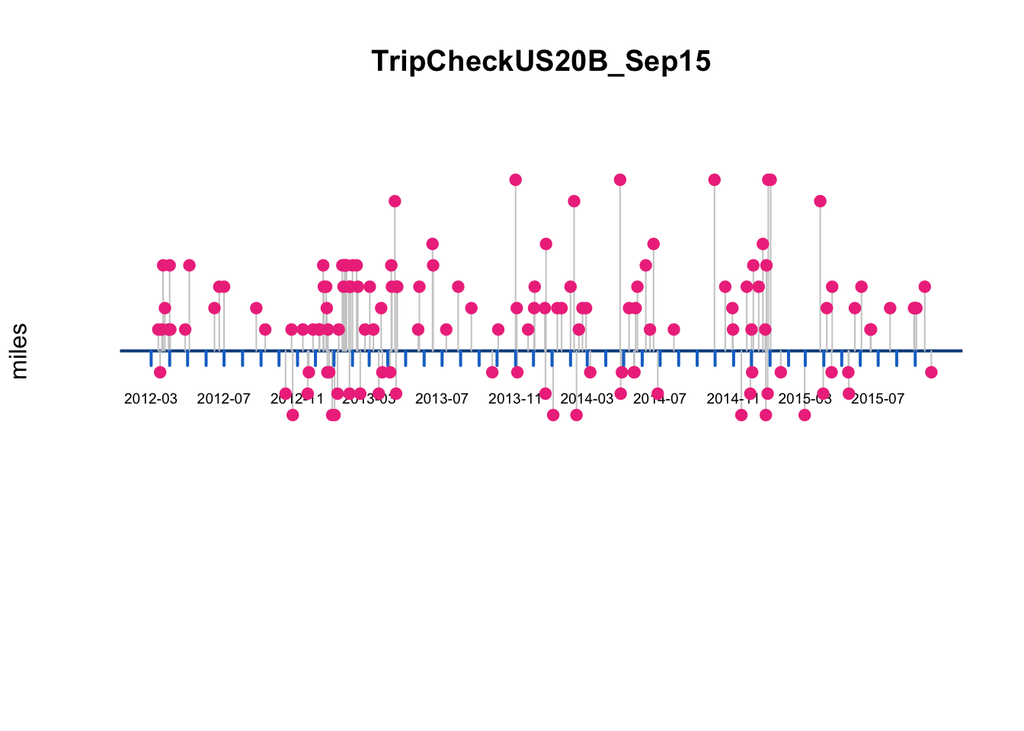

### Histogram of accident locations

This plot shows the distribution of accidents as measured by the distance from the point of reference Santiam Pass Summit. While the number of accidents on the West side outweigh those on the wast, there appears to be a strong bias to the distribution.

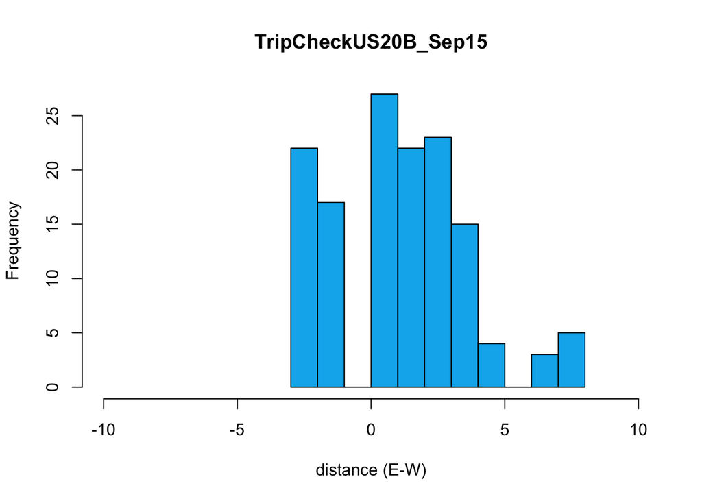

### Conclusion

This is a first analysis of this data. Will compare it to other road segments.